# Reciprocal transplants reveal asymmetric local adaptation of Himalayan Rhododendron approaching elevational range limit - Mainali - 2023 - Ecosphere - Wiley Online Library

[Ecosphere](https://esajournals.onlinelibrary.wiley.com/journal/21508925)

[Volume 14, Issue 7](https://esajournals.onlinelibrary.wiley.com/toc/21508925/2023/14/7) e4563

[figure not shown]

ARTICLE

Open Access

# Reciprocal transplants reveal asymmetric local adaptation of Himalayan *Rhododendron* approaching elevational range limit

[Kumar Mainali](https://esajournals.onlinelibrary.wiley.com/authored-by/Mainali/Kumar),

[Subodh Adhikari](https://esajournals.onlinelibrary.wiley.com/authored-by/Adhikari/Subodh),

[Sushila Shrestha](https://esajournals.onlinelibrary.wiley.com/authored-by/Shrestha/Sushila),

[Michael C. Singer](https://esajournals.onlinelibrary.wiley.com/authored-by/Singer/Michael+C.),

[Joseph White](https://esajournals.onlinelibrary.wiley.com/authored-by/White/Joseph),

[Camille Parmesan](https://esajournals.onlinelibrary.wiley.com/authored-by/Parmesan/Camille),

First published: 13 July 2023

https://doi.org/10.1002/ecs2.4563

**Handling Editor:** Charles D. Canham

## Abstract

As plant species expand their upper limits of distribution under current warming, some retain both traditional climate space and biotic environment while others encounter novel conditions. The latter is the case for *Rhododendron campanulatum*, a woody shrub that grows both above and below treeline at our study site in the Eastern Himalayas where a very conspicuous, stable treeline was defined by a nearly contiguous canopy of tall *Abies spectabilis* trees, many of which are over a century old. Prior work showed that treeline had remained static in this region while *R. campanulatum* expanded its elevational range limit. We tested local adaptation of *R. campanulatum* by performing reciprocal transplants between the species' current elevational range limit (4023 m above sea level [asl]) and just above treeline (3876 m asl). Contrary to expectation, the coldest temperatures of late winter and early mid-spring were experienced by plants at the lower elevation: *R. campanulatum* at species' limit (upper site) were covered by snow for a longer period (40 more days) and escaped the coldest temperatures suffered by conspecifics at treeline (lower site). The harsher spring conditions at treeline likely explain why leaves were smaller at treeline (15.3 cm<sup>2</sup>) than at species limit (21.3 cm<sup>2</sup>). Contrary to results from equivalent studies in other regions, survival was reduced more by downslope than by upslope movement, again potentially due to extreme cold temperatures observed at treeline in spring. Upslope transplantation had no effect on mortality, but mortality of species limit saplings transplanted downslope was three times higher than that of residents at both sites. A general expectation is that locals should survive better than foreign transplants, but survival of locals and immigrants at our species limit site was identical. However, those species limit saplings that survived the transplant to treeline grew faster than both locals at treeline and the transplants at species limit. Overall, we found asymmetric adaptation: Compared with treeline saplings, those at species limit (147 m above treeline) were more tolerant of extremes in the growing season but less tolerant of extremes in winter and early mid-spring, displaying local adaptation in a more complex manner than simply home advantage, and complicating predictions about impacts of future regional climate change.

## INTRODUCTION

Current climate change is shifting temperature isotherms upward in mountains (Beniston, 2003; IPCC, 2007, 2014), inducing responses from species in distribution and phenology (Chen et al., 2011; Parmesan & Yohe, 2003). Included in the distributional responses is a general trend for population extinctions and range contractions at lower elevational boundaries (Wiens, 2016) and for range expansions driven by colonization at upper boundaries (Freeman & Freeman, 2014; Grabherr et al., 1994; Lenoir et al., 2008; Liang et al., 2016; Lustenhouwer et al., 2018; Parmesan, 1996).

Studies of plant evolution at expanding range margins are still rare (Lustenhouwer et al., 2018). However, plants typically show high spatial variation in phenology, growth, and ecophysiology, often in response to elevational gradients (Aitken et al., 2008; Keller et al., 2011), and there is a long history of research on phenotypic variation of plants across elevational transects. Investigations of the adaptive significance and mechanistic basis of within-species variation across elevations have typically used common garden experiments or reciprocal transplants among natural habitats (Adhikari et al., 2021; Clausen & Hiesey, 1958; Hargreaves et al., 2014; Johnson et al., 2022; Körner, 2012; Lee-Yaw et al., 2016; Midolo & Wellstein, 2020; Ohsawa & Ide, 2008; Turesson, 1922). Results from these studies have been diverse. Plants sampled from different elevations may not differ at all (Fetched et al., 2000) or, when they do differ, the divergence can be mostly in heritable traits (Clausen & Hiesey, 1958), in plasticity (Pfennigwerth et al., 2017), or in both (Van Nuland et al., 2020).

Here, we contribute to the sparse literature on the mechanistic basis and adaptive significance of variation around expanding elevational range limits of plants by reporting results of reciprocal transplants performed on a tall woody shrub, *Rhododendron campanulatum* D. Don, that is currently expanding its range limit in the Himalayas (Rana et al., 2017; Singh et al., 2018). Our study area is the vicinity of treeline in Langtang National Park, Nepal (Mainali et al., 2020), a region with negligible influence of direct anthropogenic effects such as land use changes. Although there have been hundreds of studies of reciprocal transplant performed across geographic and elevational ranges worldwide (see Hargreaves et al., 2014; Lee-Yaw et al., 2016; Midolo & Wellstein, 2020 for review and synthesis of those studies), to the best of our knowledge, this is the first reciprocal transplant experiment conducted in the Eastern Himalayas excluding dry Tibetan plateau and one of the very few in the tropical and subtropical geographies of the world (see Datta et al., 2017 for a reciprocal transplant experiment conducted in the Western Himalayas, and Shen et al., 2014, and Cui et al., 2018 for the reciprocal transplant experiments in Tibet).

Treeline researchers define three upper elevational boundaries. Following Körner and Paulsen (2004), the virtual line representing the uppermost boundary of closed forest canopy is designated as timberline. Above timberline, trees are found in clumps. The virtual line that connects the highest clumps is designated as treeline (Körner & Paulsen, 2004). Treeline is not identical to species limit: globally, saplings of various tree species have been observed above treeline (Gaire et al., 2014; Körner, 2012; Singh et al., 2018). Therefore, the uppermost boundary at which any individual (of any size or class) of a tree species is found is defined as the species limit. The position of treeline depends on how a “tree” is defined; Körner and Paulsen (2004) defined a treeline as the virtual line connecting the uppermost patches of upright tree individuals that are at least 3 m tall.

Seeds of tree species at treeline are carried upslope where abiotic and biotic elements of the habitat affect whether and how the seeds grow. Tree saplings establishing above treeline face a new set of environmental conditions including different amounts of radiation, longer snowpack duration at higher elevation, and different moisture regimes, soil types, and biotic interactions. For example, under the canopy of tall trees (e.g., *Abies spectabilis*) below treeline in the Himalayas, ground vegetation is close to nonexistent, except in gaps (Mainali et al., 2020). Trees at or below treeline, with their open architecture, have little resistance to free atmospheric convection, resulting in tree canopy temperatures only slightly above ambient air temperatures (Körner, 2012). Tall trees below treeline also cast dense shade with their thick canopies, further contributing to a cold microhabitat for saplings (Körner, 2012); note however that krummholz and adult-sized clusters of trees can also have the opposite effect (McIntire et al., 2016). Conversely, the ground vegetation above treeline is dense (Mainali et al., 2020) and temperatures experienced by short vegetation, with its compact canopy, can decouple from free atmospheric convection, resulting in substantial solar heating that offers beneficial facilitation to saplings (Körner & Paulsen, 2004; Liang et al., 2016; Mainali et al., 2020; Shen et al., 2018). By studying 87 mountain summits belonging to 10 mountain ranges in Europe, the GLORIA project found that tree canopy temperature is coupled with the atmospheric temperature but ground vegetation maintains a higher temperature (Bürli et al., 2021). Körner (2003) reported heating of alpine cushions to 20°C above air temperature and of shrubs and alpine grass to 10°C warmer. Because of these differences between environments above and below treeline in their aerodynamic properties and warmth by sunlight, saplings experience colder air below treeline than above it until they become tall enough (trees) to couple with the free atmospheric convection.

Seed dispersal upslope from treeline is likely random; however, the seedling establishment process differentially filters out the genotypes that do not tolerate local conditions (Davis & Shaw, 2001). This selective sieving of unfit genotypes can continue for several seasons, leaving in the colonized habitat only those individuals that can tolerate year-round conditions. Therefore, natural selection on thermal traits such as cold tolerance will differ between populations above and below treeline. Response to such selection can be plastic (Anderson et al., 2021; Münzbergová et al., 2017; Pfennigwerth et al., 2017) and/or genetic (de Villemereuil et al., 2018; Gonzalo-Turpin & Hazard, 2009). In the present case, genetic response is possible, provided that appropriate genetic variation exists in the source populations below treeline. Not surprisingly, a global meta-analysis of reciprocal common garden experiments shows that the climate-regime-induced differences in trait values (survival, reproduction, biomass, and growth)—an expression of local adaptation—were more distinct and stronger (higher Hedge's *d*) for experiments conducted with seedlings than with seeds (Lortie & Hierro, 2022). Some of the aspects of genetic differentiation of the saplings, potentially resulted due to the selection pressure of local edaphoclimatic conditions, can be estimated with reciprocal transplant experiments that yield responses from plants based on their genetic adaptation, plasticity, or both. Therefore, these experiments are the standard practices used to determine the adaptive potential of plant populations from one place when grown in a different place with a different set of climatic, environmental, and biotic conditions (Johnson et al., 2022; Lortie & Hierro, 2022).

We aim to determine whether and how saplings of *R. campanulatum*, the most common tree species at the treeline ecotone of the Eastern Himalayas in Nepal (Mainali et al., 2020; Polunin & Stainton, 1984), are adapted to living above the current treeline. We assessed this by performing a reciprocal transplant of saplings between two sites: one immediately above treeline (i.e., treeline site) and a second near the species limit (i.e., species limit site) located at an elevational distance of ~147 m above the first site. Specifically, we test the following hypotheses: (1) Because the saplings from species limit sites are dormant during other seasons, these individuals are better adapted to growing season climate extremes than saplings from treeline site. (2) Adaptation to extreme climate conditions during the growing season may not necessarily offer year-round protection, which requires strategies to avoid, rather than tolerate, extremes, for example, by remaining dormant during unfavorable conditions because breaking dormancy could exacerbate problems.

## MATERIALS AND METHODS

### Study site

The study was conducted in Nepal's Langtang National Park, 50 km north of the Kathmandu Valley (treeline site: 85.36532° E, 28.07401° N, 3876 m above sea level [asl]; species limit site: 85.36738° E, 28.0717° N, 4023 m asl). The park (1710 km<sup>2</sup> in area) has an elevation ranging from 1000 to 7200 m (Fox et al., 1996) and has been relatively undisturbed by humans for centuries. While cattle grazing occurs at lower elevation within the park areas, our study sites, located at the treeline ecotone (at or above 3876 m asl), are distant from the nearest human settlements (>7-h walk for the locals). Little human impact is observed at the sites that are 4–5 h walk from the nearest, and least favored, tourist trail. The study was conducted on a north-facing slope of a mountaintop with a wide belt of geographic space available at and above treeline. At our study sites, a very conspicuous treeline was defined by the presence of a nearly contiguous canopy of tall and over a century old *A. spectabilis* trees (Mainali et al., 2020); hence, by definition, it is also a “timberline.” This space above treeline was completely covered by plants, mostly by ground vegetation dominated by *Rhododendron anthopogon*, with a fraction of it occupied by individuals of several tree species (Figure 1). The vertical distance between the treeline and the top of the mountain was >400 m. The uppermost part of this space above species limit site had no tree species, not even small saplings (additional details about the site are provided in Mainali et al., 2020).

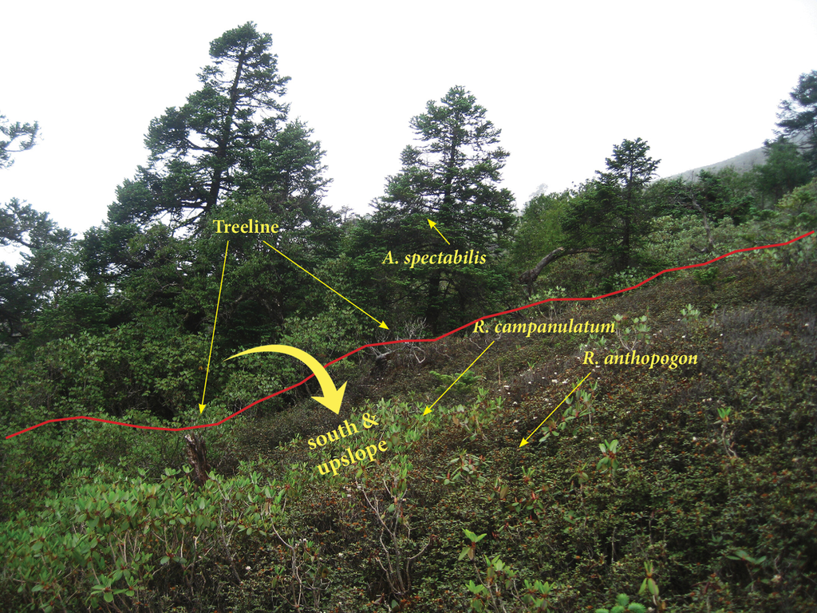

**FIGURE 1**

Treeline site right above the virtual treeline is comprised of a sharp boundary of tall *Abies spectabilis* in downhill. *Rhododendron campanulatum* (uphill) is seen both in isolation and in cluster above treeline. A thick surrounding vegetation of *R. anthopogon* likely offers warm microenvironment to the seedlings of *R. campanulatum*. Image credit: K. Mainali.

In accordance with the regional climate warming (IPCC, 2007, 2014), gridded monthly estimates by Climate Research Unit (TS3.10, 0.5° spatial resolutions) show that the climate at our study sites has indeed been warming since ca. 1970 (Mitchell & Jones, 2005). This has been supported by the nearest weather station with complete long-term data in Kathmandu, ~50 km south from the field site that also indicates regional warming, whether analyzed for annual mean temperatures or separate seasonal trends (Shrestha et al., 2014). In addition, more frequent warm nights and a decline in cooler weather are predicted for the region (IPCC, 2007, 2014). No systematic trend in precipitation has been determined in the long term (Shrestha et al., 2014). However, an increase in variability of precipitation has been predicted for the region (IPCC, 2007, 2014).

### Study species and co-occurring vegetation

*R. campanulatum* D. Don is an evergreen broad-leaved woody shrub, sometimes classified as a tree. The plant achieves a height of 2–6 m (Figure 1) and is distributed between 3000 and 4400 m asl in the Himalayan Mountains (Polunin & Stainton, 1984). At our study site and in other upper distributional limits of trees in the Himalayas, *R. campanulatum* is a highly abundant plant species associated with another abundant tree species, *A. spectabilis* (D. Don) Mirbel (Himalayan silver fir; locally known as *gobre salla*, *talis patra*, or *thingre salla*). *A. spectabilis* is a tall evergreen conifer growing in a wide elevational belt of 2800 and 4000 m asl (Polunin & Stainton, 1984). The tree has a single main axis holding whorls of branches, each of them profusely branched and densely foliated. It is the tallest (Figure 1) and one of the most abundant tree species in the high Himalayas. At our study site, *A. spectabilis* presents a sharp distributional boundary of tall trees forming a conspicuous treeline. Below the treeline, *R. campanulatum* is found growing under the canopy of the much taller trees of *A. spectabilis*. Above the treeline, isolated saplings of *A. spectabilis* are found only occasionally with extremely rare tall trees. In the absence of the canopies of taller trees above treeline, *R. campanulatum* saplings can be found growing as isolated individuals or in cluster. The *A. spectabilis* treeline is likely to have been stable for over a century (Mainali et al., 2020), with its trees in the top 50-m elevational band being 35–170 years old (mean age 86 years) and several trees being more than a century old right at the edge of the sharp treeline (K. Mainali, unpublished data). Other associated plant species at the study site included *Betula utilis*, *Prunus* sp., *Salix* sp., and *Sorbus microphylla*.

For this study, we define *R. campanulatum* plants that were <2 m tall as “saplings,” while the taller plants are designated as “mature plants.” Our transplanted plants were 10–50 cm tall. Very small plants, often <15 cm, are considered as “seedling.” However, making a distinction between seedling and saplings in this size range would not add to our study. So, we used the term “sapling” to denote all the short plants we studied.

### Experimental design and measurements

Two study sites were set up on a mountain slope, arranged to be very similar in slope, aspect, and soil properties (Figure 1). Each of the sites measured ~50 m along the contour of elevation and ~35 m toward the top of the mountain, spanning 15 m in elevational distance. The lower site (Figure 1), hereafter referred to as the “treeline site,” was situated ~45 m (elevational distance 16 m) above the treeline at 3876 m, established at a sufficient distance from the treeline to exclude any canopy effect of trees on the site. The other site, hereafter designated as “species limit site,” was set up at 147 m (elevational distance) above the treeline site. A few *R. campanulatum* saplings were found further upward from the species limit site. However, the species limit site was the highest location on the mountain where we could find enough healthy saplings.

In 2010, we transplanted saplings, transferring plants between species limit and treeline sites. Within each site, we randomly sampled 40 healthy saplings of 10–50 cm in height, with no easily noticeable damage. We maintained similarity in plant heights between the two sites by stratified sampling. In each site, we assigned the saplings to two groups of equal size. One group was then randomly chosen to be transplanted to the other site; we define these saplings as “treatment transplants” and the group as “foreign” at the site where they were planted. The other group of saplings was dug up and replanted at the same spot, retained in their site of origin as control; we define these saplings as “control transplant” and the group as “resident” or “home.” All saplings that were dug up were excavated with the entire root system intact and ~0.03 m<sup>3</sup> (1 **×** 1 **×** 1 ft) of soil around them. The transplanted saplings along with the soil were placed in the emptied spots in the foreign site such that 20 saplings from one site exchanged their locations with 20 saplings from the other site. While transplanting the saplings, care was taken to physically orient the saplings in the same direction as they were in their extracted location.

In situ measurements were taken before and after transplanting the saplings, and exactly one year later. For each sapling, the following measurements were recorded: plant height, total number of healthy and unhealthy leaves if any (some plants had a few leaves with a small portion damaged or necrotic), length of newly added main axis in the current growing season, length of previous year's shoot expansion (the current topmost internode below the newly added shoot), length and width at the widest part of all the leaves produced in the current growing season, and four measurements of the spread of the crown at every 45° interval in angle. From each plot we also collected ~100 healthy leaves, at least two per plant, from a new random set of undisturbed plants of similar height to the transplants. These leaves were pressed between piles of paper, brought back to lab, and dried. A high-resolution image of each leaf was then analyzed with Adobe Photoshop CS 5.5 to determine the length, width, and area with a precision of 0.085 mm (1/300 inch). The model derived from destructive sampling of these leaves was used for estimating the area of leaves in the transplanted saplings.

We also took measurements of biotic and abiotic factors as potential covariates of the measured traits of target saplings. We set up 1-m-diameter plots, each centered on control and treatment saplings used in the experiment. In each plot, we measured the proportion of the ground surface covered with vegetation (which was almost always comprised of a congener species *R. anthopogon*), height of surrounding vegetation as measured at four points on the periphery of the plot, slope, aspect, and soil fertility. For soil fertility, we collected four samples of soil (100–200 g in total) from each plant after the plant was dug up with the samples and mixed to homogenize. The soil samples were provided to the lab of Nepal Agricultural Research Center, Kathmandu where the concentrations of soluble N, P, K, and organic matter in the soils of both sites were measured. Temperature measurements were collected for each plot (toward the center in a location that represents the slope and aspect of the overall plot) every hour for 9 months with a data logger (HOBO Pendant Temperature/Light Data Logger 8K, Onset Computer Corp, Bourne, MA, USA). Each data logger was securely mounted on a sturdy pole and placed 22 cm above the ground toward the middle of the study site. Although we initially installed two data loggers per site, only one in each site retrieved the temperature for a sufficiently long duration.

Of the 80 study saplings (40 saplings per site, with 20 as control/replanted and 20 as moved/transplanted to another site), 19 plants were either uprooted, damaged, or missing before their measurements in the second year. We found that the animals liked to chew the aluminum tag we used; the uprooted plants had their tag with dental marks and crumbled. These 19 plants were excluded from the analysis. Of the remaining 61 saplings, 19 were dead during the second field visit (mortality calculated from these numbers), leaving a total of 42 plants intact and available for calculation of growth rates and other variables.

A noticeable limitation of this study is the sample size. We conducted the experiment at an elevation where hypoxia (effective oxygen concentration ~12% compared with 21% at sea level) was a substantial constraint for the team to carry saplings along with ~35 kg of soil (27,000 cm<sup>3</sup> per sapling) between the two sites (walking distance >400 m). We exhaustively searched for healthy saplings of our criteria at species limit site on one flank of the mountain, which was suitable for conducting this experiment because of the availability of the two sites to compare. We could not find another flank in the vicinity that provided both sites on one flank. Given these constraints, we were only able to transplant a total of 80 saplings for our study.

### Analysis

The experimental sapling size range of 10–50 cm height encompassed most of the existing saplings in both the species limit and the treeline sites. This design enhances the generalization of the finding of this study because of the size range in saplings. Regression analysis included plant height as a potential covariate. Repeated measurements after a year allowed a paired design in the sense that the “before” and “after” transplant measurements can be compared within a plant, removing the noise of plant-to-plant variability in height. For these variables, the measurements of the previous year were subtracted from that of the latter year, allowing a treatment-wise and site-wise difference in annual growth/change. For the variables that did not permit paired design, we used plant height as a covariate in the analysis.

Data analysis and plotting were performed in R ×64 4.0.0 (The R Project for Statistical Computing) using the following packages: e1071, fields, graphics, grDevices, grid, ineq, mvpart, plotrix, plyr, reshape, and sciplot. We applied the following statistical tests for various analyses: Welch two-sample *t* test, Mann–Whitney–Wilcoxon test, two-way ANOVA, and log-likelihood ratio test (*G* test) of independence on a contingency table, multiple linear regression, and regression trees. The choice of the test depended on model diagnostics for its assumptions of the given data. Details about the tests used are provided in the figure captions. In all tests, labels for the levels of various factors are used as below: for plant origin, “Species limit” or “Treeline,” for transplant site “home/control,” or “foreign/moved,” and for status “dead” or “alive.”

## RESULTS

### Leaf size, covariates, and significant explanatory variables before transplant

The measurement of saplings at the beginning of the experiment (before transplant) showed that the recently produced leaves (in the summer months before our field visit in August) had a higher average size at species limit site (21.3 cm<sup>2</sup>) than at treeline site (15.3 cm<sup>2</sup>) (Figure 2a). The average total area of such leaves in a plant was also higher in species limit population (75.25 cm<sup>2</sup>) than in treeline plants (48.51 cm<sup>2</sup>) (Figure 2b). The two sites were not significantly different for sapling height (25.38 cm in species limit and 27.47 cm in treeline; Figure 3a) or the crown size of the saplings (18.11 cm in species limit and 16.60 cm in treeline; Figure 3b). However, compared with species limit, the surrounding vegetation in 1-m-diameter plot of treeline site occupied more area (33.16% in species limit and 78.24% in treeline; Figure 3c) and was taller on average (17.28 cm in species limit and 35.19 cm in treeline; Figure 3d). The number of damaged leaves per individual (scaled by the total number of leaves) was not significantly different between the two sites (43.1% in species limit and 34.9% in treeline; Figure 3e). Regression tree analysis on aggregated data of the two sites showed that a sapling's total area of leaves produced in the current year was significantly predicted only by surrounding vegetation cover, explaining 28% of the variance in leaf area; the relationship between total area and surrounding vegetation cover was negative (Figure 4).

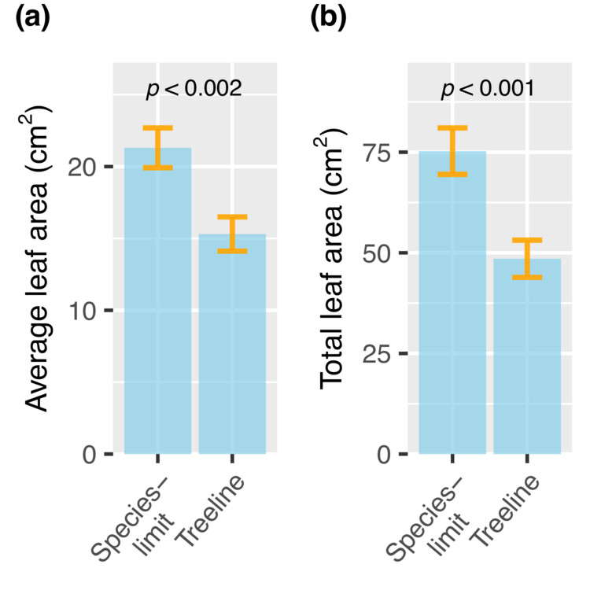

**FIGURE 2**

Area of leaves that were recently produced in the growing season of summer preceding the first field visit, as measured before transplant in the first week of August 2010; mean ± 1 SE. (a) Average area of an individual leaf; Welch two-sample *t* test; *t* = 3.287, df = 76.323, *p* = 0.0015. (b) Total area of leaves in a plant; Welch two-sample *t* test; *t* = 3.6157, df = 74.479, *p* = 0.00054. Leaf area was estimated with length and width. A linear regression model developed with a sample of leaves from both sites to predict area with length and width of leaf explained ~98% of the variation in leaf area in both sites (see Appendix S1: Figure S1).

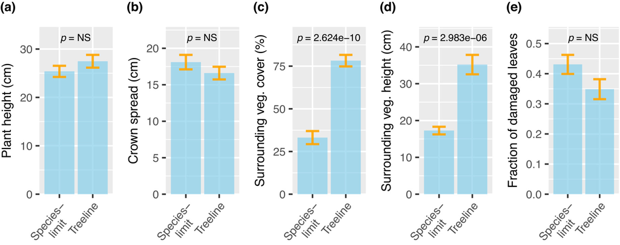

**FIGURE 3**

Covariates and potential explanatory variables for the observed differences among saplings in Figure 2, as measured before transplant; mean ± 1 SE. (a) Plant height; Welch two-sample *t* test; *t* = −1.188, df = 76.622, *p* = 0.238. (b) Crown spread (diameter of crown measured four times at the widest part at an angular interval of 45°); Welch two-sample *t* test; *t* = 1.137, df = 75.412, *p* = 0.259. (c) Surrounding vegetation (veg.) cover (fraction of the area covered by vegetation); Welch two-sample *t* test; *t* = −8.834, df = 33.850, *p* ≤ 0.001. (d) Surrounding veg. height; Welch two-sample *t* test; *t* = −6.314, df = 20.899, *p* ≤ 0.001. (e) Fraction of damaged leaves (ratio of the number of damaged leaves to that of total leaves); Mann–Whitney–Wilcoxon test, *W* = 960.500, *p* = 0.123.

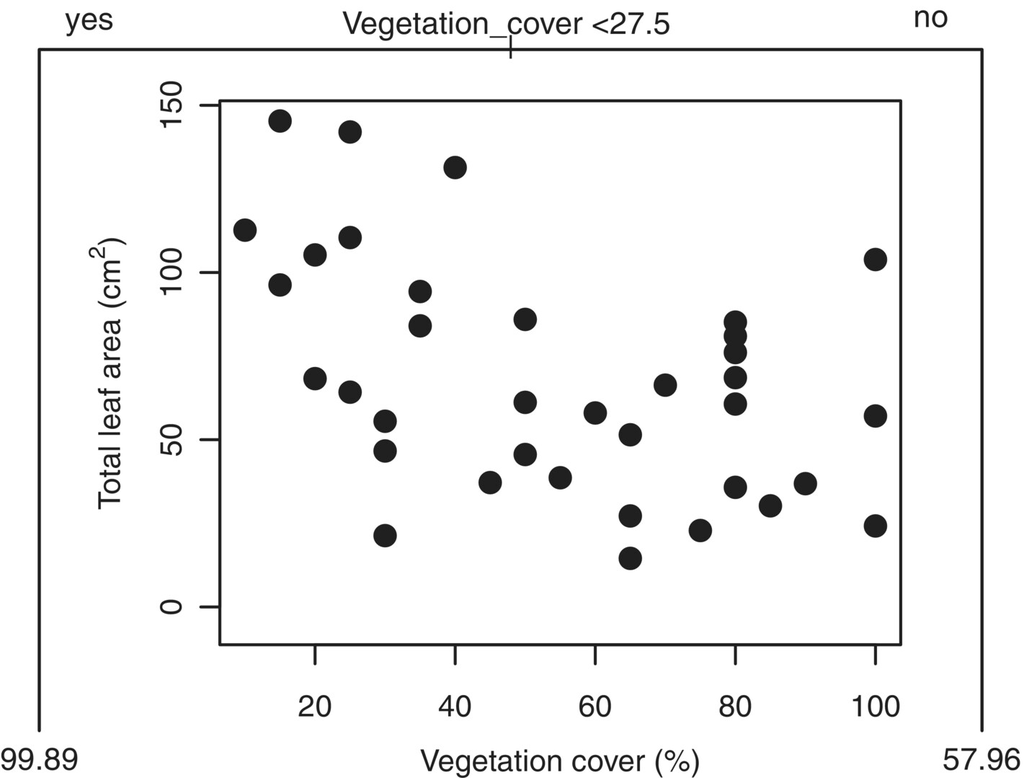

**FIGURE 4**

Regression tree analysis of sapling's total area of current year's leaves with its potential explanatory variables, measured before transplantation. Fully grown regression tree model was pruned with cross validation to save the minimum error tree. Slope, aspect, elevation, sapling height, surrounding vegetation cover, and surrounding vegetation height were entered into the model as potential predictors. The only significant predictor retained in the pruned tree was surrounding vegetation cover, explaining 28% of the variation in leaf area. The surrounding vegetation cover of 27.5% splits the regression tree (see “Vegetation_cover <27.5” at the top of the split) into two groups of mean total leaf area of 99.89 and 57.96 cm<sup>2</sup> (indicated at the leaf nodes or at the end of the two splits).

### Growth and mortality after a year of transplant

Data collected one year after the transplant revealed the cumulative year-long response of the saplings after transplantation. A *G* test on the three-way contingency table showed that interaction between the three factors—plant origin (species limit or treeline), transplant site (home or foreign), and plant status (dead or alive)—was significant (*p* = 0.036), indicating an asymmetric response between plants of different origin at the two sites (Figure 5a). Subsequent pair-wise analyses showed that there was a significantly higher mortality for saplings moved from species limit to treeline site than for controls, that is, saplings from species limit replanted at species limit (58.8% in transplanted and 16.7% in control plants; *p* = 0.019; Figure 5a). When the controls on the two sites were compared, their in situ mortality was not different. So, the elevation of origin did not affect mortality.

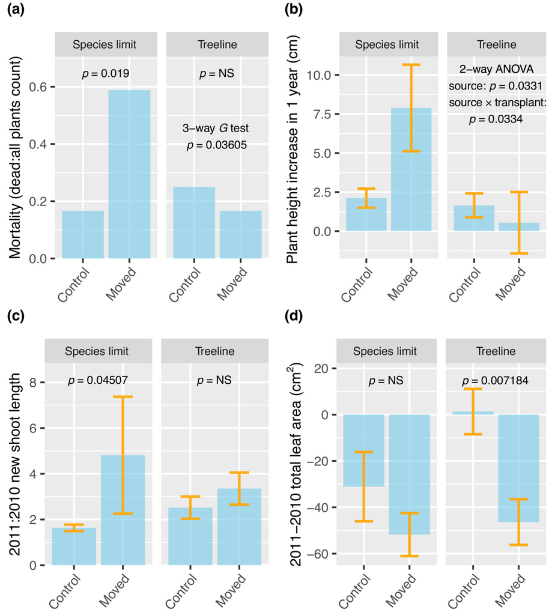

**FIGURE 5**

Various parameters of plant growth and mortality measured a year after reciprocal transplantation; mean ± 1 SE. (a) Mortality (ratio of the number of dead plants to that of all plants) based on plant origin and transplant operation (control vs. moved). A log-likelihood ratio test (*G* test) of independence on a three-way contingency table to evaluate the joint independence of plant origin, transplant site, and status (live or dead) shows a significant interaction of plant origin and transplant operation on mortality; *G* = 8.542, χ<sup>2</sup> df = 3, *p* = 0.036. Within the species limit population, *G* test on a two-way contingency table: *G* = 5.488, χ<sup>2</sup> df = 1, *p* = 0.019, whereas within treeline, *G* test on a two-way contingency table: *G* = 0.31369, χ<sup>2</sup> df = 1, *p* = 0.575. (b) A two-way ANOVA shows significant main effects of origin (*p* = 0.0331) and of the origin × transplant operation interaction (*p* = 0.0334) on annual plant growth (plant height increase in 1 year). (c) The ratio of current year's new shoot growth to that of last year's (2011:2010 new shoot length) was significantly different for control versus moved populations of the species limit site (Mann–Whitney–Wilcoxon test, *W* = 34, *p* = 0.045) but not for the treeline populations (*W* = 70.5, *p* = 0.255). (d) Change in total leaf area in 2011 minus in 2010 (2011–2010 total leaf area). The species limit population lost similar amount of leaf area for control versus moved plants (Mann–Whitney-Wilcoxon test, *W* = 14, *p* = 0.366), whereas the treeline population lost more leaf area when moved (Mann–Whitney–Wilcoxon test, *W* = 11, *p* = 0.007).

For surviving saplings, results indicated that the species limit population, when moved downhill, showed generally higher productivity than the treeline population at either site. Specifically: (1) the annual growth of saplings was significantly positively impacted by the source, in general (main effect of a two-way ANOVA, *p* = 0.0331) and importantly, the growth of species limit saplings in response to transplant (control vs. transplant) was significantly higher than the growth of treeline saplings in response to transplant (two-way ANOVA, origin × transplant interaction, *p* = 0.0334; Figure 5b); (2) compared with the previous year, the new shoot expansion in the current year was higher for species limit saplings transplanted to treeline than for controls at species limit (*p* = 0.045, Figure 5c); however, such effect of transplant was not observed for treeline saplings (Figure 5c); and (3) saplings transplanted from treeline to species limit lost more leaf area than did the control at treeline (*p* = 0.007; Figure 5d), whereas species limit saplings lost comparable leaf area whether they were retained in home or transplanted to foreign site (Figure 5d).

### Soil fertility and air temperature

We found no site-wise differences in the concentrations of soluble N, P, K, and organic matter in the soils (not shown in figure). However, the air temperature measurement shows that the data logger (placed 22 cm above ground) was buried under snowpack on January 19 at species limit but on February 5 at treeline (Figure 6). In spring, the data logger was exposed to the air starting on May 1 at species limit but on April 8 at treeline. This collectively gives the species limit site (at 22 cm height) an extra 17 days in winter and 23 days in spring to be protected under the snowpack when the treeline site is still exposed to air. We have adopted the convention that the term “spring” refers to the months of March through May at our sites, consistent with its definition elsewhere for Langtang (e.g., https://www.weather-atlas.com/en/nepal/langtang-climate).

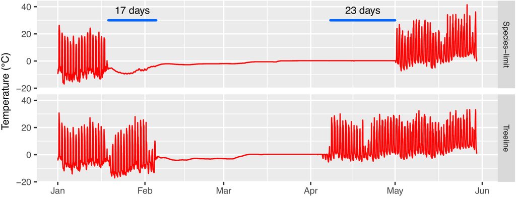

**FIGURE 6**

Hourly temperature recorded at the two sites at the height of 22 cm. Daily cycle of temperature is depicted by the swing of line until data logger is buried under the snow, yielding a flat line. In late winter, the temperature of snow is below zero but it remains at zero for many weeks as spring approaches. The plants were buried under snowpack from January 19 to May 1 at the species limit site, but from February 5 to April 8 at the treeline site. This protected the plants at the species limit site under the snowpack for an extra 17 days in winter and 23 days in spring when the treeline site was still exposed to much colder air temperatures and harsher conditions daily.

## DISCUSSION

Due to climate change, treeline species are shifting upward, but there are limited studies regarding how these newly migrated populations experiencing new set of abiotic and biotic conditions perform as compared with the treeline populations. In our reciprocal transplant experiment conducted in Nepal Himalayas, *R. campanulatum* plants from the treeline and species limit sites along an elevational gradient of ~150 m performed differently, showing asymmetric local adaptations of these two populations. Specifically, species limit saplings suffered significantly higher mortality when moved down to the treeline site compared with their home. However, those saplings at the species limit that survived the transplant at treeline grew faster than the locals (at treeline) and the transplants at species limit.

If extremes of cold are judged as harsh conditions, then plants at the treeline suffered harsher conditions than those at even higher elevations at the species limit. This was because species limit plants were protected by snowpack both during the coldest January ambient conditions and during cold days in April, when treeline plants were exposed to air for 23 days before those at the species limit (Figure 6; see Appendix S1: Figure S2 for an alternate version of Figure 6 showing hourly data point). During spring thaw, the earlier exposure of saplings at treeline experienced a strong diurnal temperature variation associated with the early season when saplings at higher elevations were protected from these temperature extremes for longer period being buried under snowpack. The exposure of treeline saplings to freezing conditions of spring can cause frost damage to plant tissues (leaf necrosis was a routine observation in our field site), and the plants without adequate mechanisms to protect themselves from freezing can have higher mortality (Sakai & Larcher, 2012). The freezing conditions of early spring can also create transpirational challenges for plants if the soil remains frozen, which severely limits the water uptake during spring when the plants actually may experience increased transpiration rates due to cold, dry air (Larcher, 2003).

On the contrary, the beneficial effects of snowpack in winter (observed more at species limit site) have previously been demonstrated by Saarinen and Lundell (2010), who measured winter damage to plants (electrolyte leakage in leaves) and found that plants under a moderate snowcap had less damage than exposed plants. A lack of early-season freezing condition has been previously shown to benefit seedling survival in treeline forest (Shen et al., 2018), further confirming the role of snowpack in offering protection to our species limit populations during early spring.

Given the aforementioned strong differences between the two sites in our study, it is not surprising that plants from the two sites performed differently, though we cannot know to what extent those differences were based in plasticity and genetic differentiation. The treeline plants are selected to tolerate more extreme weather during late winter and spring compared with the species limit population. This precisely explains why the species limit population suffered a higher mortality when moved down to treeline.

Our findings are mostly echoed (for the response of species limit population) by a recent meta-analysis aggregating data of 49 vascular plant species from 38 transplant studies: plants transplanted downwards showed higher mortality than the local individuals, but produced higher biomass and height compared with their site of origin, whereas the plants transplanted upwards had reduced plant growth and survival than the local individuals (Midolo & Wellstein, 2020). Another transplant experiment conducted in the Tibetan plateau observed decreased survival and increased productivity of the plant community when transplanted to warmer sites (Cui et al., 2018). The transplanted species limit saplings in our study that did survive at lower elevation grew faster than the residents surrounding them, suggesting a trade-off between growth and survival. We lack enough information to combine survival and growth into a single fitness measure, so we cannot say whether species limit plants had overall higher or lower fitness when transplanted downhill: they had improved performance in growth but reduced performance in survival.

Experiments conducted across elevational gradients in various mountain ranges showed that plant mortality was very often influenced by local adaptation (Byars et al., 2007; Giménez-Benavides et al., 2007; Lortie & Hierro, 2022). In previous common garden experiments, plants from higher elevations grew more slowly than those from lower elevations (Burger, 1926; Byars et al., 2007; Gonzalo-Turpin & Hazard, 2009). This genetic differentiation of plant growth across elevational gradients is generally attributed to local adaptation of certain traits, for example, growth, height, morphotype (de Villemereuil et al., 2018), or trade-off between vigor and environmental stress resistance. Trade-off between growth rate and freezing tolerance has been shown to exist at latitudinal limits of tree species both in North America (Loehle, 1998) and in Europe (Larsen, 1986). Following the logic of this trade-off, our results suggest that during the spring, species limit saplings use less resources in freezing resistance than treeline saplings. This, along with more favorable growing season conditions at treeline site, could explain the faster growth of transplanted species limit saplings compared with the residents at the treeline site.

Leaf sizes in natural settings were significantly different across the short elevational gradient of ~150 m between the two study sites. These results differ from those in the literature (many species in other mountains) in both magnitude and direction. Previous reports found that leaf size decreased with increasing elevation and the clines were much less steep than in the present study (Körner, 2012; Körner et al., 1986; Körner & Cochrane, 1985). Similarly, surrounding vegetation cover was significantly lower at species limit site than at treeline. Although elevation was entered as a potential predictor of leaf area, the regression tree model retained only surrounding vegetation cover as the significant predictor of leaf area, exhibiting a negative relationship: larger leaves where cover was less. Other studies using neighbor removal experiments have demonstrated that surrounding vegetation provides facilitation to plants above treeline (Choler et al., 2001) or in other stressful environments (Grassein et al., 2014). Still, other studies show that surrounding vegetation might offer climatic amelioration to seedlings, although the competition slows tree recruitment in the long run (Liang et al., 2016).

The exact nature of the effect of surrounding vegetation on the plants in our sites cannot be determined with our current design. A comprehensive analysis (Heynen et al., 2016) of temperature lapse rate in the same general area (Langtang) a year after the completion of our experiment shows that the temperature drops at the rate of 0.0060°C/m in pre-monsoon (March 1–June 14), and 0.0050°C/m in post-monsoon (October 1–November 30); these two windows of times very closely match the temperature record availability in our data in the season when surrounding vegetation may have ecological roles (so, we excluded deep winter). With these lapse rates, the two sites (147-m elevational gradient) are expected to have a temperature difference of 0.88°C in pre-monsoon and 0.74°C in post-monsoon. However, our observed temperature differences indicate that the treeline site was 2.1°C warmer than species limit site (4.86 vs. 2.76°C) in pre-monsoon and 2.13°C warmer (4.33 vs. 2.2°C) in post-monsoon. Hence, we have a plot-level warming of treeline site (2.1–0.88 = 1.22°C in pre-monsoon and 2.13–0.74 = 1.39°C in post-monsoon) not explained by adiabatic cooling. This observation of warming effect of surrounding vegetation has been observed in several other studies. Facilitation, alone, however, cannot explain the growth responses in our experiment; saplings from two sources had different growth rates when grown together in the treeline site. Nor can the differences in leaf size and growth rate be attributed to soil fertility, as the concentrations of soluble N, P, K, and organic matter in the soils from the two sites were similar.

Among the plants that were able to survive after a year, species limit population did not lose more total leaf area when moved down (Figure 5d, left panel) but treeline population lost more total leaf area when moved up (Figure 5d, right panel). We cannot provide a specific reason for these asymmetric responses. However, we do not believe that this was a result of transplantation shock because we followed the same transplantation procedure in the entire experiment. The effect of digging up and replanting of plants is expected to affect all plants similarly (both controls and transplanted at both sites). It is unknown whether transplantation shock interacts with some aspects of plant traits or climatic conditions, resulting in larger loss of total leaf area in some groups.

### Eco-evolutionary implications

A recent decade-long observation of Tibetan mountains reported that early-season freezing events were generally more frequent, more intense, and long-lasting in the warmer years within a slope (Shen et al., 2022). Further exploring the mechanism of this paradoxical observation, this study found that air humidity and soil moisture in pre-monsoon season are reduced by high solar radiation and air temperature in daytime, which effectively lowers the nighttime temperatures to extreme values (Shen et al., 2022). If this holds true for the Himalayas, then an increase in early-season freezing events is likely with climate warming, further distancing the two populations at our study sites in their ability to tolerate harsh spring and late winter conditions.

While climate warming can have its implications to asymmetric adaptations, it can also affect the overall process of colonization of new habitat at range boundaries, which is a slow process that involves dispersal, establishment, population growth, and reproduction (Jackson & Overpeck, 2000). In the present study, seed dispersal to both the treeline site (immediately above the edge of treeline) and the species limit site (150 m above treeline site) could have come either from the same mother plants below treeline and/or from the scattered mature, reproductive trees that existed above treeline. An elevational gradient of 150 m on a gentle slope presents no geographic barrier to seed dispersal of *R. campanulatum*, whose seeds are small, light, and scaly, and so easily carried by wind. Seed dispersal is followed by seedling establishment, which differentially removes the genotypes that do not tolerate local conditions (Davis & Shaw, 2001).

Climate-change-induced range expansions at the upper boundaries driven by colonization is a general trend observed globally (Freeman & Freeman, 2014; Grabherr et al., 1994; Lenoir et al., 2008; Liang et al., 2016; Lustenhouwer et al., 2018; Parmesan, 1996). Such expansions to new habitats likely present a novel set of environment and climate where the populations with evolutionary potential go through an adaptation. A species range with heterogeneous genetic variation can inflate the genetic variance of marginal population with migration if drift is not strong (Connallon & Sgrò, 2018), which thereby increases the evolutionary potential and so expansion of species range (Barton, 2001). On the contrary, declining population densities at the margin means genetic drift is more likely to substantially reduce genetic variation, effectively limiting the range expansion (Polechová & Barton, 2015). Multiple empirical and experimental studies show that marginal populations often have lower genetic variation (Eckert et al., 2008), and a combination of low genetic variation and high gene flow can diminish adaptation at species range (Bridle et al., 2009; Hendry & Taylor, 2004), limiting the range expansion. Without additional data, not much can be said about the adaptation of *R. campanulatum* at our species limit site. However, *R. campanulatum*, which is smaller in size compared with other tree species such as *A. spectabilis*, has high density at the treeline and above it, potentially facilitating adaptive evolution.

### Potential impact of sample size

Sample size issue has been widely discussed in ecological research, but not all studies can be treated similarly. We began the experiment with 80 saplings. Of these, we lost 19 in a year for reasons other than natural death (mostly due to animal eating). There is no reason to believe that these lost saplings had a different growth rate than the rest at each site. After a year, we had 61 saplings available for analysis at two sites. This sample size is less than desired, especially for two-way ANOVA. So, the question is: how does a relatively small sample size impact the analysis and ecological inference? A small sample size is still a representative of the population if it is selected without bias, as is the case with our study. In that situation, there are two aspects of the analysis with obvious undesirable consequences: significance of the hypothesis testing and precision of parameter estimates. With a relatively wider CI, a small sample size has a low statistical power inflating the risk of type II error, that is, failure to reject a null hypothesis when it is false or failure to detect a true effect that actually exists (Kutner et al., 2005; Lemoine et al., 2016). In such situations, it would be incorrect to conclude the effect does not exist (Steel et al., 2013). We presented a series of statistically significant relationships, making the aforementioned challenge of small sample size irrelevant to our study.

## CONCLUSION

Our transplant experiment yields results that are markedly different from those of other experiments conducted around elevational range limits. Reciprocal transplants failed to meet the expectation of simple local adaptation that would result in individuals doing better at “home” than at the “foreign” site. Individuals from the species limit site, if survived, performed better when moved downhill than they did at home, and also outperformed the locals. Whether the differences and asymmetries that we found stem from genetic differences, epigenetic factors, and/or plastic responses during early life (e.g., acclimation) cannot be addressed with this experimental design. However, regardless of the root nature, the asymmetric responses suggest that populations of *R. campanulatum* at species limit locations have undergone an adaptive response to living at the extremes of the species' boundary that result in higher growth when moved to more interior (and presumably more favorable) environments. The upper elevational boundary of *R. campanulatum* is rapidly shifting upward (Mainali et al., 2020). However, the present study indicates that strong differences still exist between individuals across a short elevational gradient, with saplings at the uppermost limit of the species range being more tolerant to extreme climate conditions of growing season but less tolerant to climatic extremes of winter and early spring compared with saplings only 150 m lower in elevation at the treeline. How these asymmetric responses of populations to seasonal climatic extremes shape the future species growth at the boundary of species range will largely depend on the nature of the future climate change in the area, complicating an inference about upward shift of the species.

## AUTHOR CONTRIBUTIONS

Kumar Mainali conceived the ideas. Kumar Mainali, Joseph White, and Camille Parmesan designed methodology. Kumar Mainali and Sushila Shrestha conducted the field experiments and collected the data. Kumar Mainali analyzed the data. Kumar Mainali, Michael C. Singer, Camille Parmesan, and Subodh Adhikari led the writing of the manuscript. All authors contributed critically to the drafts and gave final approval for publication.

## ACKNOWLEDGMENTS

Many graduate and undergraduate students in Nepal assisted in the field project: Ravi Sharma, Ravindra Pandeya, Raju Bista, Manoj Raut, Niroj Basnet, Saroj Neupane, and Lokendra Karki. Nima Sherpa and Layul Tamag provided assistance with logistics in field sites. The research was funded by the following grants to Kumar Mainali: National Science Foundation Doctoral Dissertation Improvement Grant (DEB-1210767), and University of Texas at Austin Graduate Program in Ecology, Evolution and Behavior grant. This work was also supported by the following grants to Camille Parmesan: grant 1049208 from the National Science Foundation, grant 09-NICCR-1077 from the Department of Energy, a French Make Our Planet Great Again award (ANR-17-MPGA-0007), and the Laboratoires d'Excellences (LABEX) TULIP (ANR-10-LABX-41). An earlier version of the manuscript was reviewed by Shishir Paudel, whose insightful and helpful comments are appreciated.

## CONFLICT OF INTEREST STATEMENT

The authors declare no conflicts of interest.

[figure not shown]

[Volume14, Issue7](https://esajournals.onlinelibrary.wiley.com/toc/21508925/2023/14/7)

July 2023

e4563